# Module2 - Rmarkdown Document 1

Prashant Dey

11/9/2018

# This is a level one header

## R Markdown

### this is a level three header

Here is link to [GOOGLE](https://google.com/)

Here is a word in **bold** and *italics*

Here is a word in *BOLD Italics*

When we compile the the document, we are using the `rmarkdown` package.

```
2+2
mean(c(1,2,3,4))
```

Here is an example of a non-numbered list:

- Breakfast
  - food
    - eggs
    - toast
    - bacon
  - drink
    - apple juice
- Lunch
  - taco
- Dinner
  - baked chicken
  - broccoli
  - rice

Here is an example of a numbered list:

1. Breakfast
   1. food
      1. eggs
      2. toast
      3. bacon
   2. drink
      1. apple juice
2. Lunch
   1. taco
3. Dinner
   1. baked chicken
   2. broccoli
   3. rice

Here is an example of a blockquote:

> This is a block quote. This paragraph has two lines.
> 1. This is a list inside a block quote.
> 2. Second item.

Here is an example of a nested blockquote:

> This is a block quote. This paragraph has two lines.

> > This text is nested

Here is an example of code in a blockquote:

> ```
> 2+2
> mean(c(1,2,3,4,5))
> ```

```r
head(cars)
```

```
##   speed dist
## 1     4    2
## 2     4   10
## 3     7    4
## 4     7   22
## 5     8   16
## 6     9   10
```

## Package

```r
library(ggplot2)
library(plotly)
```

## Figures

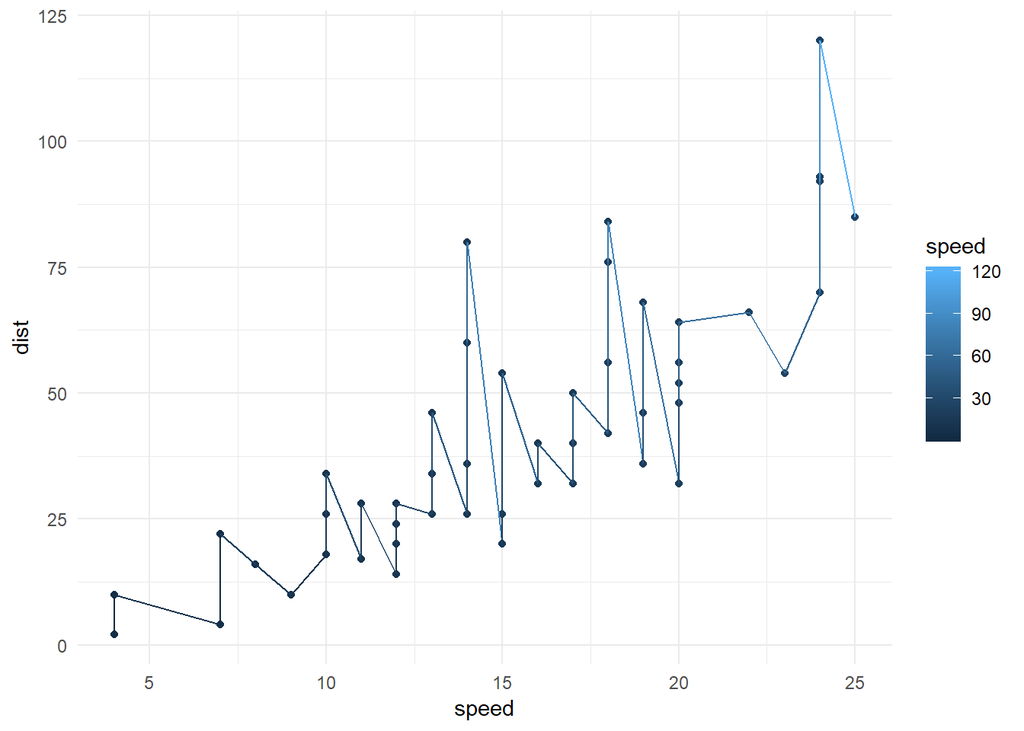

```r
cars %>%
  ggplot(aes(x = speed, y = dist))+
  geom_point(aes(color = speed))+
  geom_line(aes(color = dist))+
  theme_minimal()
```

## Equation

$$Returns = Price_{t}/ Price_{t-1} - 1$$

or

$$Returns = \ln(\frac{Price_{t}}{Price_{t-1}})$$

# Images, Vidoes using markdown syntax

## Insert Images

[figure not shown]

Sunstar

## Insert Videos

For HTML only

[figure not shown]

# Images, Vidoes using knitr syntax

[figure not shown]

```r
knitr::include_graphics("./sunstar.png")
```

```r
knitr::include_graphics("./sunstar.gif")
```

[output not shown]

## Insert text with some footnotes

Here is a footnote reference [^1] and another [^2]

Here is an inline footnote [^3]

[^1]: Here is the footnote.
[^2]: Here’s one with multiple blocks.
[^3]: Inlines notes are easier to write, since you don’t have to pick an identifier and move down to type the note.